# Bank Churn Prediction

Christopher Nindyo

2022-08-28

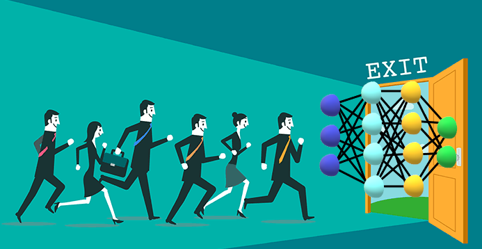

# Objective

I am going to make bank churn prediction. It is the dataset of a U.S. bank customer for getting the information, this particular customer will leave bank or not. This dataset is from U.S. bank, given like Credit Score, Age, Gender, and many more.

# Preparation

First, call library we need

```r
library(dplyr)
library(tidyverse)
library(gmodels)
library(gtools)
library(class)
```

Library to handle imbalance data

```r
library(caret)
```

## Data import

I use dataset from Kaggle. It’s called “Bank Customer Churn Prediction”. Or you can download from [here](https://www.kaggle.com/datasets/shantanudhakadd/bank-customer-churn-prediction).

```r
churn <- read.csv('Churn_Modelling.csv')
glimpse(churn)
```

```
#> Rows: 10,000
#> Columns: 14
#> $ RowNumber       <int> 1, 2, 3, 4, 5, 6, 7, 8, 9, 10, 11, 12, 13, 14, 15, 16,…
#> $ CustomerId      <int> 15634602, 15647311, 15619304, 15701354, 15737888, 1557…
#> $ Surname         <chr> "Hargrave", "Hill", "Onio", "Boni", "Mitchell", "Chu",…
#> $ CreditScore     <int> 619, 608, 502, 699, 850, 645, 822, 376, 501, 684, 528,…
#> $ Geography       <chr> "France", "Spain", "France", "France", "Spain", "Spain…
#> $ Gender          <chr> "Female", "Female", "Female", "Female", "Female", "Mal…
#> $ Age             <int> 42, 41, 42, 39, 43, 44, 50, 29, 44, 27, 31, 24, 34, 25…
#> $ Tenure          <int> 2, 1, 8, 1, 2, 8, 7, 4, 4, 2, 6, 3, 10, 5, 7, 3, 1, 9,…
#> $ Balance         <dbl> 0.00, 83807.86, 159660.80, 0.00, 125510.82, 113755.78,…
#> $ NumOfProducts   <int> 1, 1, 3, 2, 1, 2, 2, 4, 2, 1, 2, 2, 2, 2, 2, 2, 1, 2, …
#> $ HasCrCard       <int> 1, 0, 1, 0, 1, 1, 1, 1, 0, 1, 0, 1, 1, 0, 1, 0, 1, 1, …
#> $ IsActiveMember  <int> 1, 1, 0, 0, 1, 0, 1, 0, 1, 1, 0, 0, 0, 0, 1, 1, 0, 1, …
#> $ EstimatedSalary <dbl> 101348.88, 112542.58, 113931.57, 93826.63, 79084.10, 1…
#> $ Exited          <int> 1, 0, 1, 0, 0, 1, 0, 1, 0, 0, 0, 0, 0, 0, 0, 0, 1, 0, …
```

Important things from data :

1. `RowNumber` : Row Number Of dataset
2. `CustomerId` : CustomerID is given
3. `Surname` : Surname of the customer
4. `CreditScore`: Credit Score of customer
5. `Geography` : location of customer
6. `Gender` : Gender whether male or female
7. `Age` : Age of the customer
8. `Tenure` : From how many years customer is in bank
9. `Balance` : Average balance of customer
10. `NumOfProducts` : Number of bank product facilities customer is using
11. `HasCrCard` : Customer whether has credit card or not
12. `IsActiveMember`: Customer whehter is active member or not
13. `EstimatedSalary` : Customer’s estimated salary
14. `Exited` : Customer whether exit or not

Check the data first

```r
head(churn)
```

|  | RowNumber | CustomerId | Surname | CreditScore | Geography | Gender | Age | Tenure | Balance | NumOfProducts | HasCrCard | IsActiveMember | EstimatedSalary | Exited |
| --- | --- | --- | --- | --- | --- | --- | --- | --- | --- | --- | --- | --- | --- | --- |
| 1 | 1 | 15634602 | Hargrave | 619 | France | Female | 42 | 2 | 0.00 | 1 | 1 | 1 | 101348.88 | 1 |
| 2 | 2 | 15647311 | Hill | 608 | Spain | Female | 41 | 1 | 83807.86 | 1 | 0 | 1 | 112542.58 | 0 |
| 3 | 3 | 15619304 | Onio | 502 | France | Female | 42 | 8 | 159660.80 | 3 | 1 | 0 | 113931.57 | 1 |
| 4 | 4 | 15701354 | Boni | 699 | France | Female | 39 | 1 | 0.00 | 2 | 0 | 0 | 93826.63 | 0 |
| 5 | 5 | 15737888 | Mitchell | 850 | Spain | Female | 43 | 2 | 125510.82 | 1 | 1 | 1 | 79084.10 | 0 |
| 6 | 6 | 15574012 | Chu | 645 | Spain | Male | 44 | 8 | 113755.78 | 2 | 1 | 0 | 149756.71 | 1 |

# Data Cleansing

As we can see the data still not clean, the data type is quite not right. Some of the columns are not needed like RowNumber. CustomerId, and Surname.

```r
churn_clean <-  churn %>%
  select(-c(RowNumber, CustomerId, Surname )) %>%
  mutate_if(is.character, as.factor) %>%
  mutate(
    HasCrCard = as.factor(HasCrCard),
    IsActiveMember = as.factor(IsActiveMember),
    Exited = as.factor(Exited),
    Exited = factor(Exited, levels = c(0, 1),
                    labels = c("Churn",
                               "Not Churn")))

glimpse(churn_clean)
```

```
#> Rows: 10,000
#> Columns: 11
#> $ CreditScore     <int> 619, 608, 502, 699, 850, 645, 822, 376, 501, 684, 528,…
#> $ Geography       <fct> France, Spain, France, France, Spain, Spain, France, G…
#> $ Gender          <fct> Female, Female, Female, Female, Female, Male, Male, Fe…
#> $ Age             <int> 42, 41, 42, 39, 43, 44, 50, 29, 44, 27, 31, 24, 34, 25…
#> $ Tenure          <int> 2, 1, 8, 1, 2, 8, 7, 4, 4, 2, 6, 3, 10, 5, 7, 3, 1, 9,…
#> $ Balance         <dbl> 0.00, 83807.86, 159660.80, 0.00, 125510.82, 113755.78,…
#> $ NumOfProducts   <int> 1, 1, 3, 2, 1, 2, 2, 4, 2, 1, 2, 2, 2, 2, 2, 2, 1, 2, …
#> $ HasCrCard       <fct> 1, 0, 1, 0, 1, 1, 1, 1, 0, 1, 0, 1, 1, 0, 1, 0, 1, 1, …
#> $ IsActiveMember  <fct> 1, 1, 0, 0, 1, 0, 1, 0, 1, 1, 0, 0, 0, 0, 1, 1, 0, 1, …
#> $ EstimatedSalary <dbl> 101348.88, 112542.58, 113931.57, 93826.63, 79084.10, 1…
#> $ Exited          <fct> Not Churn, Churn, Not Churn, Churn, Churn, Not Churn, …
```

Check the missing value

```r
churn_clean %>% is.na() %>% colSums()
```

```
#>     CreditScore       Geography          Gender             Age          Tenure
#>               0               0               0               0               0
#>         Balance   NumOfProducts       HasCrCard  IsActiveMember EstimatedSalary
#>               0               0               0               0               0
#>          Exited
#>               0
```

The dataset has no missing values. It is okay to continue.